# Final project of STAT184-Zhefeng He

# I.Data Access

### Following are packages we gonna use in the project.

### Loading data collected from:

### http://www.ungei.org/resources/files/unesco_mexico124210eo.pdf This demonstrates the school attendence of Mexico

### http://www.electionresources.org/mx/deputies.php?election=2000&state=32

### Loading x1:97 election map, x2:2000 election map, x3: school attandenceof 1990s

```r
library(readxl)
library(ggplot2)
library(httr)
library(dplyr)
library(gridExtra)
library(tidyverse)
library(repmis)
library(httr)
x3 <- read_excel("per.xlsx")
View(x3)
x2<-read_excel("20poll.xlsx")
View(x2)
x1<-read_excel("97poll.xlsx")
View(x1)
```

### Here WE inpsect the infomration of datasets and check variables.

```r
summary(x1)
```

```
     name                er97
 Length:31          Min.   :0.0450
 Class :character   1st Qu.:0.1790
 Mode  :character   Median :0.2380
                    Mean   :0.2588
                    3rd Qu.:0.3705
                    Max.   :0.4810
```

```r
summary(x2)
```

```
     name               er20
 Length:31          Length:31
 Class :character   Class :character
 Mode  :character   Mode  :character
```

```r
summary(x3)
```

```
     name             perceatend
 Length:31          Min.   : 1.500
 Class :character   1st Qu.: 4.250
 Mode  :character   Median : 6.600
                    Mean   : 6.265
                    3rd Qu.: 7.750
                    Max.   :13.100
```

```r
str(x1)
```

```
Classes ‘tbl_df’, ‘tbl’ and 'data.frame':   31 obs. of  2 variables:
 $ name: chr  "Sonora" "Baja California Sur" "Chihuahua" "Coahuila" ...
 $ er97: num  0.305 0.187 0.4 0.298 0.238 0.252 0.366 0.229 0.354 0.416 ...
```

```r
str(x2)
```

```
Classes ‘tbl_df’, ‘tbl’ and 'data.frame':   31 obs. of  2 variables:
 $ name: chr  "Sonora" "Baja California Sur" "Chihuahua" "Coahuila" ...
 $ er20: chr  "#43.2%" "#25.7%" "#47.1%" "#43.3%" ...
```

```r
str(x3)
```

```
Classes ‘tbl_df’, ‘tbl’ and 'data.frame':   31 obs. of  2 variables:
 $ name      : chr  "Sonora" "Baja California Sur" "Chihuahua" "Coahuila" ...
 $ perceatend: num  3.3 3.9 4.9 4.6 6.9 7.5 6.7 7.4 6.1 8 ...
```

### As there are special characters in election 20, so using regular expression to clear it.

### Also, in x1, the percentage number is expressed in“0.XXX”, mutiple it by 100.

```r
x2 <-
  x2 %>%
  mutate(er20 = gsub(pattern = "[#,%]", replacement = "", er20)) %>%
  mutate(er20=as.numeric(er20))
x2
```

| name | er20 |
| --- | --- |
| Sonora | 43.2 |
| Baja California Sur | 25.7 |
| Chihuahua | 47.1 |
| Coahuila | 43.3 |
| Durango | 38.2 |
| Zacatecas | 23.7 |
| San Luis Potosi | 42.2 |
| Nayarit | 27.2 |
| Aguascalientes | 51.5 |
| Guanajuato | 55.8 |

[output cut: 21 more lines]

```r
x1 <-
  x1 %>%
  mutate(er97=er97*100)
x1
```

| name | er97 |
| --- | --- |
| Sonora | 30.5 |
| Baja California Sur | 18.7 |
| Chihuahua | 40.0 |
| Coahuila | 29.8 |
| Durango | 23.8 |
| Zacatecas | 25.2 |
| San Luis Potosi | 36.6 |
| Nayarit | 22.9 |
| Aguascalientes | 35.4 |
| Guanajuato | 41.6 |

[output cut: 21 more lines]

# Data sets combination

### Here we join two tables for further analysis.

```r
me <-
  x1 %>%
  inner_join(x2, by=c("name")) %>%
  inner_join(x3, by=c("name"))
me
```

| name | er97 | er20 | perceatend |
| --- | --- | --- | --- |
| Sonora | 30.5 | 43.2 | 3.3 |
| Baja California Sur | 18.7 | 25.7 | 3.9 |
| Chihuahua | 40.0 | 47.1 | 4.9 |
| Coahuila | 29.8 | 43.3 | 4.6 |
| Durango | 23.8 | 38.2 | 6.9 |
| Zacatecas | 25.2 | 23.7 | 7.5 |
| San Luis Potosi | 36.6 | 42.2 | 6.7 |
| Nayarit | 22.9 | 27.2 | 7.4 |
| Aguascalientes | 35.4 | 51.5 | 6.1 |
| Guanajuato | 41.6 | 55.8 | 8.0 |

[output cut: 21 more lines]

# Create the variable called “change” to evalute.

```r
me2 <-
  me %>%
  mutate(change=(er20-er97))
me2
```

| name | er97 | er20 | perceatend | change |
| --- | --- | --- | --- | --- |
| Sonora | 30.5 | 43.2 | 3.3 | 12.7 |
| Baja California Sur | 18.7 | 25.7 | 3.9 | 7.0 |
| Chihuahua | 40.0 | 47.1 | 4.9 | 7.1 |
| Coahuila | 29.8 | 43.3 | 4.6 | 13.5 |
| Durango | 23.8 | 38.2 | 6.9 | 14.4 |
| Zacatecas | 25.2 | 23.7 | 7.5 | -1.5 |
| San Luis Potosi | 36.6 | 42.2 | 6.7 | 5.6 |
| Nayarit | 22.9 | 27.2 | 7.4 | 4.3 |
| Aguascalientes | 35.4 | 51.5 | 6.1 | 16.1 |
| Guanajuato | 41.6 | 55.8 | 8.0 | 14.2 |

[output cut: 21 more lines]

### Gather the me2 dataset to collect election result under same variable “name”.

### Generate the graphs to show the distribution of elections data.

### As you can see a general increase on election 2000 compared to election 1997.

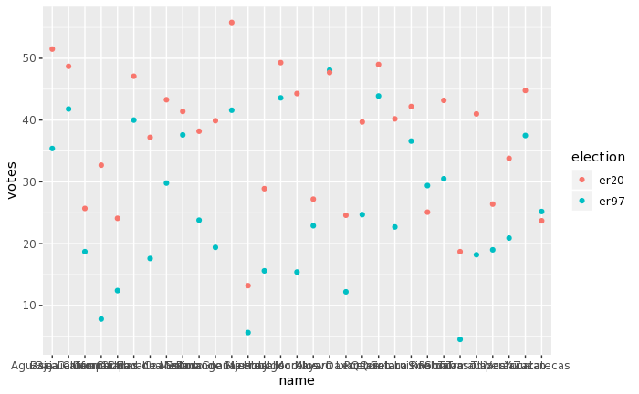

```r
me1<-
  me2 %>%
  group_by(name) %>%
  gather( key=election, value=votes, er97, er20 )
me1 %>%
  ggplot(aes(x=name, y=votes, color=election)) +
  geom_point()
```

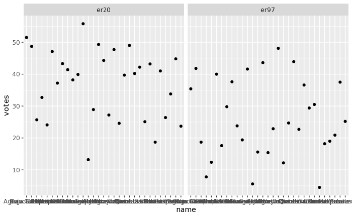

```r
me1 %>%
  ggplot(aes(x = name, y = votes)) +
  geom_point()+
  facet_wrap(~election)
```

### Here we measure central tendency and standard deviation of Independent variable with mean and sd.

### so the mean of school attendance is 6.264516% and deivation of positive & negative 2.608646 %.

```r
mean(me2$perceatend)
```

```
[1] 6.264516
```

```r
sd(me2$perceatend)
```

```
[1] 2.608646
```

### Back to the me2 dataset.

### Rearrange the me2 in the rank of most votes changing state for further research

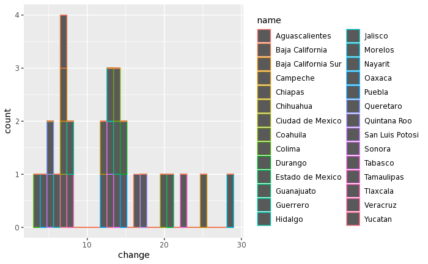

```r
me2 <-
  me2 %>%
  filter(change >= 0) %>%
  group_by(name) %>%
  arrange(desc(change))
me2 %>%
  ggplot(aes(x = change, color=name)) +
  geom_histogram()
```

### Using the me2 to generate the distribution of dependent variables by independent variables

### the density tells us a rough negative relationship.

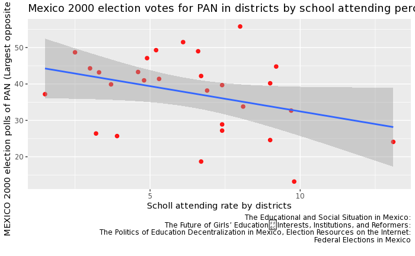

```r
p1<-ggplot(me2,aes(x=perceatend,y=er20))+
  geom_point(size=2, color='red', alpha=0.9)+  #Better setting size and color
  geom_smooth(method='lm')+
  labs(x="Scholl attending rate by districts",
       y="MEXICO 2000 election polls of PAN (Largest opposite party)",
       title = "Mexico 2000 election votes for PAN in districts by school attending percentage in districts",
       caption = "The Educational and Social Situation in Mexico:
The Future of Girls’ Education，Interests, Institutions, and Reformers:
The Politics of Education Decentralization in Mexico, Election Resources on the Internet:
Federal Elections in Mexico
       ")
p1
```

### building a liner model to analyze the relationship

### Low R-square means the relationship is not significant.

```r
fg1<-lm(change~perceatend,data = me2)
summary(fg1)
```

```
Call:
lm(formula = change ~ perceatend, data = me2)

Residuals:
    Min      1Q  Median      3Q     Max
-9.0018 -5.9091  0.5493  2.8487 15.6115

Coefficients:
            Estimate Std. Error t value Pr(>|t|)
(Intercept)  13.9233     3.2809   4.244 0.000247 ***
perceatend   -0.2116     0.4794  -0.441 0.662618
---
Signif. codes:  0 ‘***’ 0.001 ‘**’ 0.01 ‘*’ 0.05 ‘.’ 0.1 ‘ ’ 1

Residual standard error: 6.65 on 26 degrees of freedom
Multiple R-squared:  0.007436,  Adjusted R-squared:  -0.03074
F-statistic: 0.1948 on 1 and 26 DF,  p-value: 0.6626
```

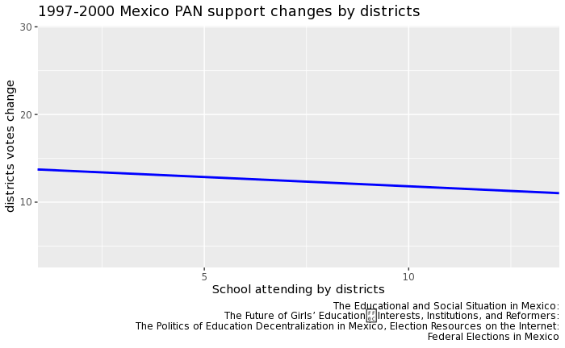

```r
pg2<-ggplot(me2,aes(x=perceatend,y=change))+
  xlim(min(me2$perceatend),max(me2$perceatend))+
  ylim(min(me2$change),max(me2$change))+
  geom_abline(intercept =fg1$coefficients[1], #a+bx+e
              slope = fg1$coefficients[2],
              size=1,
              color="Blue")+
  labs(x="School attending by districts",
       y="districts votes change",
       title = "1997-2000 Mexico PAN support changes by districts",
       caption = "The Educational and Social Situation in Mexico:
         The Future of Girls’ Education，Interests, Institutions, and Reformers:
         The Politics of Education Decentralization in Mexico, Election Resources on the Internet:
         Federal Elections in Mexico")
pg2
```

### Why is not statitical signifcant?

### probably because the wide data distribution.

### the machine-learning graph verified the wide data distribution.

### This is we why cannt conclude a statical significant result.

```r
Mex <- dist(me2)
```

```
NAs introduced by coercion
```

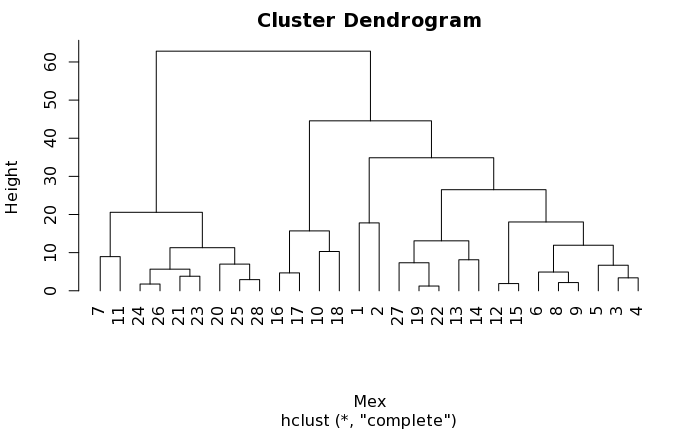

```r
hc <- hclust(Mex)
plot(hc, hang=-1)
```

### In the end, This research was motivated by the central question: what social factors contributed the vote increasing for PAN in Mexico 2000 election. This study concludes that there is no statistically significant relationship between school attendance rate and votes changing of PAN. As complexity and variety of social components, future studies should consider other factors of education to evaluate the influence of education on political actions, or including any other factors to test if they have influence on political actions, and they certainly have, how much is the effect.